# Prezentacja wyników grupy 4

Hania Kranas, Asia Zbijewska

3 lutego 2017

# Wykresy typu pie chart - prawdopodobieństwa występowania w kieszeni aktywnej

## Aminokwasów

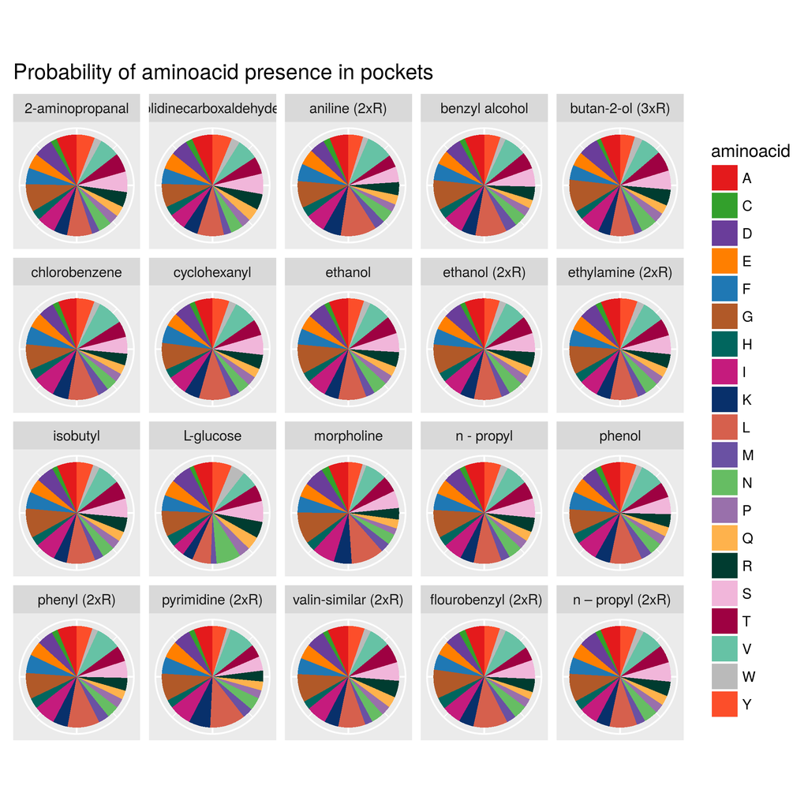

## Heteroatomów

[figure not shown]

# Wykresy typu bar plot - występowanie w białkowych kieszeniach aktywnych wszystkich grup

## Aminokwasów w odległości 3A

### Przeważają zdecydowanie:

- asparagina
- kwas asparaginowy
- lizyna
- glutamina
- arginina
- tyrozyna

[interactive chart not shown]

## Aminokwasów w odległości 5A

### Zdecydowanie przeważają:

- tryptofan
- tyrozyna

[interactive chart not shown]

Ciekawa jest tutaj wyraźna różnica w najczęściej występujących aminokwasach. Widaćjak znaczącą różnicę dało rozszerzenie zakresu..

## Heteroatomów w odległości 3A

### Zdecydowanie przeważają jony:

- wapnia
- miedzi
- żelaza(III)
- cynku

[interactive chart not shown]

### Zdecydowanie przeważają:

- miedź
- żelazo (III)
- mangan
- cynk
- MSE - selenometionina

[interactive chart not shown]

W większym otoczeniu mamy dużo większą różnorodność jonów (czego można się było spodziewać).

Jak widać obliczenia przeprowadzaliśmy również dla jonów, ale ponieważ nie wniosły zbyt wiele ciekawych informacji pomijamy je w dalszych analizach.

# Wykresy typu bar plot - występowanie w białkowych kieszeniach aktywnych

# Podział na grupy według właściwości chemicznych

## Posiadające grupę -OH, otoczenie 3A

### Przewaga:

- argininy
- lizyny

[interactive chart not shown]

Grupy z grupą hydroksylową (alkohole) preferują dodatnio naładowane otoczenie.

## Posiadające grupę -OH, otoczenie 5A

### Przewaga:

- argininy
- tryptofany
- tyrozyny

[interactive chart not shown]

Dwa aminokwasy polarne i jeden dodatnio naładowany - podejrzenie, że aminokwas polarny odwraca się w odpowiednią stronę.

## Grupy naładowane ujemnie, otoczenie 3A

### Przewaga:

- asparaginy
- kwasy asparaginowego
- lizyny
- glutaminy
- argininy

[interactive chart not shown]

## Grupy nienaładowane, otoczenie 3A

### Przewaga:

- asparaginy
- kwasy asparaginowego
- lizyny
- glutaminy
- argininy
- tyrozyna

[interactive chart not shown]

## Grupy naładowane dodatnio, otoczenie 3A

### Przewaga:

- kwasu asparaginowgo
- argininy

[interactive chart not shown]

Wyraźna różnica między ujemnie i dodatnio naładowanymi grupami.

## Grupy naładowane ujemnie, otoczenie 5A

### Przewaga:

- tyrozyny
- tryptofanu

[interactive chart not shown]

## Grupy nienaładowane, otoczenie 5A

### Przewaga:

- metioniny
- tryprofanu
- tyrozyny

[interactive chart not shown]

## Grupy naładowane dodatnio, otoczenie 5A

### Przewaga:

- tyrozyny
- tryptofanu

[interactive chart not shown]

Dla otoczenia 5A różnice nikłe różnice między dodatnio i ujemnie naładowanymi grupami - możliwe, że oddziaływania elektrostatyczne działają znacząco tylko na mniejszą odległość.

## Otoczenie 3A ligandów z grupami aromatycznymi

### Przeważają:

- kwas asparaginowy
- asparagina
- glutamina
- arginina

[interactive chart not shown]

## Otoczenie 5A ligandów z grupami aromatycznymi

### Przeważają:

- fenyloalanina
- leucyna
- metionina
- tyrozyna
- tryptofan

[interactive chart not shown]

4 aminokwasy niepolarne i 3 aminokwasy aromatyczne.  
Przeciwny wniosek: istnieje szansa występowania stackingu. Co więcej, otoczenie jest hydrofobowo-aromatyczne. Stacking występuje na większe odległości, preferuje też bycie “niezbyt blisko” dwóch pierścieni, co pozwala potwierdzić hipotezę jego występowania.

Widać że rozszerzenie oglądanego otoczenia daje istotne rezultaty.

## Otoczenia 3A ligandów o grupach hydrofobowych

### Przewaga:

- kwasu agparaginowego
- asparaginy
- argininy
- tryptofanu

[interactive chart not shown]

## Otoczenia 3A ligandów o grupach hydrofilowych

### Przewaga:

- kwasu agparaginowego
- asparaginy
- argininy
- glutaminy

[interactive chart not shown]

Różnica jednego aminokwasu - pierścieniowy hydrofobowy dla hydrofobowych i glutamina dla hydrofilowych

## Otoczenia 5A ligandów o grupach hydrofobowych

### Przewaga:

- tryptofanu
- tyrozyny
- metioniny

[interactive chart not shown]

## Otoczenia 5A ligandów o grupach hydrofilowych

### Przewaga:

- tryptofanu
- tyrozyny

[interactive chart not shown]

Różnica jednego aminokwasu - wydaje się być nieznacząca.